# Vulnerabilidade a Pobreza no Centro-Oeste do Brasil

Rafael Vinicius Curiel

11/02/2022

## Pacotes e comandos

Carregamento dos pacotes

```r
pacotes <- c("plotly","tidyverse","rgdal","spdep","knitr","kableExtra","tmap",
             "gtools","grid","knitr","kableExtra")
sapply(pacotes, require, character = T)
```

```
##     plotly  tidyverse      rgdal      spdep      knitr kableExtra       tmap
##       TRUE       TRUE       TRUE       TRUE       TRUE       TRUE       TRUE
##     gtools       grid      knitr kableExtra
##       TRUE       TRUE       TRUE       TRUE
```

## Carregamento do objeto

Carregamento da base de dados

```r
shp_co <- readOGR(dsn = "D:/datasets/shapefile_centrooeste", layer = "centrooeste_shapefile",
                  encoding = "UTF-8",
                  use_iconv = TRUE)
load("D:/datasets/dados_centro_oeste.RData")
```

### Prévia

Visualização estrutural preliminar do shapefile:

```r
head(shp_co@data)
```

```
##    ID CD_GEOCODM     NM_MUNICIP
## 0 218    5100102       ACORIZAL
## 1 219    5100201       ÁGUA BOA
## 2 220    5100250  ALTA FLORESTA
## 3 221    5100300  ALTO ARAGUAIA
## 4 222    5100359 ALTO BOA VISTA
## 5 223    5100409    ALTO GARÇAS
```

Visualização estrutural preliminar dos dados complementares:

```r
head(dados_centro_oeste)
```

```
## # A tibble: 6 x 4
##   CD_GEOCODM city         state poverty
##   <chr>      <chr>        <fct>   <dbl>
## 1 5000203    ÁGUA CLARA   MS       27.9
## 2 5000252    ALCINÓPOLIS  MS       24.4
## 3 5000609    AMAMBAI      MS       41.0
## 4 5000708    ANASTÁCIO    MS       38.4
## 5 5000807    ANAURILÂNDIA MS       39.0
## 6 5000856    ANGÉLICA     MS       23.1
```

## Manipulação

União das bases de dados

```r
shp_co@data %>%
  left_join(dados_centro_oeste, by = "CD_GEOCODM") -> shp_co@data
head(shp_co@data)
```

```
##    ID CD_GEOCODM     NM_MUNICIP           city state poverty
## 1 218    5100102       ACORIZAL       ACORIZAL    MT   58.87
## 2 219    5100201       ÁGUA BOA       ÁGUA BOA    MT   20.78
## 3 220    5100250  ALTA FLORESTA  ALTA FLORESTA    MT   25.20
## 4 221    5100300  ALTO ARAGUAIA  ALTO ARAGUAIA    MT   22.84
## 5 222    5100359 ALTO BOA VISTA ALTO BOA VISTA    MT   52.80
## 6 223    5100409    ALTO GARÇAS    ALTO GARÇAS    MT   24.34
```

Visualização gráfica preliminar da distribuição dos centróides:

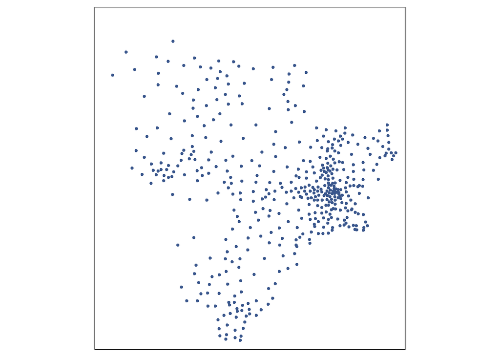

```r
tm_shape(shp = shp_co) +
  tm_dots(col = "#39568CFF", size = 0.08)
```

Estabelecimento do critério de vizinhança:

Verificação de observações duplicadas:

```r
shp_co@data$NM_MUNICIP[duplicated(shp_co@data$NM_MUNICIP)]
```

```
## [1] "MUNDO NOVO"
```

Filtro para visualização das observações duplicadas

```r
shp_co@data %>%
  filter(NM_MUNICIP == "MUNDO NOVO")
```

```
##    ID CD_GEOCODM NM_MUNICIP       city state poverty
## 1 191    5005681 MUNDO NOVO MUNDO NOVO    MS   29.41
## 2 512    5214051 MUNDO NOVO MUNDO NOVO    GO   43.77
```

Ajuste para eliniação das observações duplicadas:

```r
shp_co@data %>%
  mutate(city = paste(NM_MUNICIP, state)) -> shp_co@data
```

Estabelecimento do critério de vizinhança:

```r
nb_queen <- poly2nb(pl = shp_co,
                          queen = TRUE,
                          row.names = shp_co@data$city)
```

Resumo estatístico:

```r
summary(nb_queen)
```

```
## Neighbour list object:
## Number of regions: 466
## Number of nonzero links: 2610
## Percentage nonzero weights: 1.201901
## Average number of links: 5.600858
## Link number distribution:
##
##   1   2   3   4   5   6   7   8   9  10  11  12  13
##   4  13  40  80 119  84  57  25  20  11   6   5   2
## 4 least connected regions:
## LADÁRIO MS ANHANGUERA GO CABECEIRAS GO PORTELÂNDIA GO with 1 link
## 2 most connected regions:
## TANGARÁ DA SERRA MT MINEIROS GO with 13 links
```

Visualização gráfica preliminar:

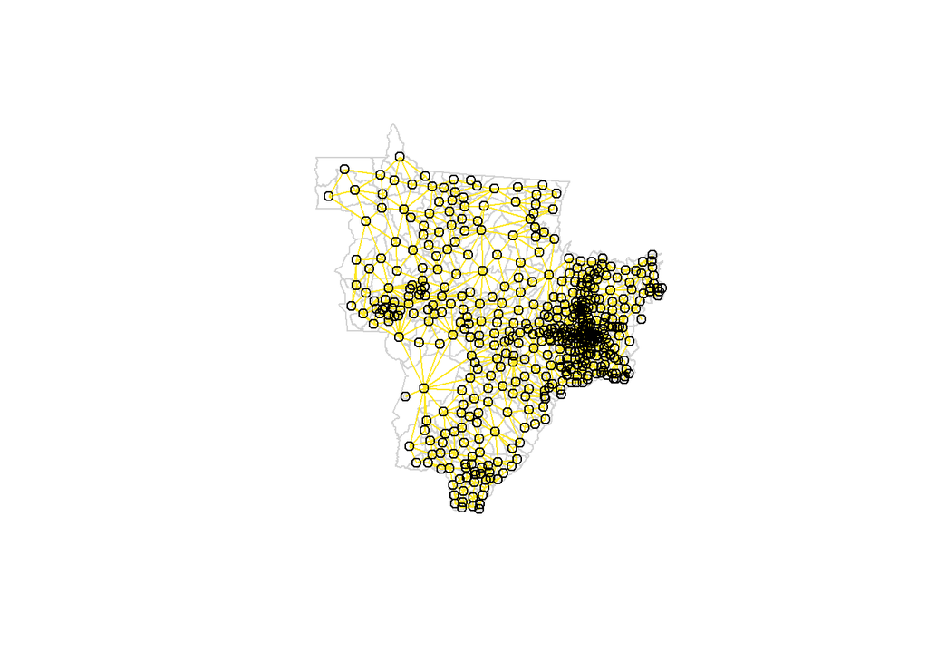

```r
plot.new()
plot(shp_co, border = "lightgray")
plot(nb_queen,
     coordinates(shp_co),
     add = TRUE,
     col = "#FDE725FF")
```

Matriz W:

```r
w_matrix_queen_linha <- nb2mat(nb_queen,
                              style = "W")
colnames(w_matrix_queen_linha) <- rownames(w_matrix_queen_linha)
```

Visualização gráfica:

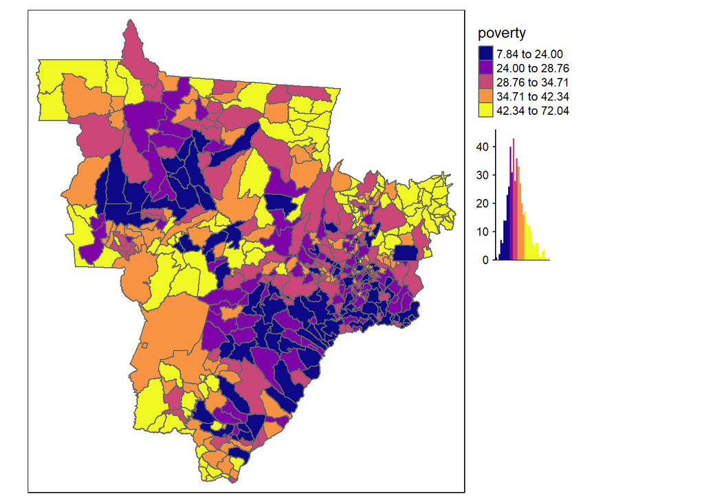

```r
pov_plot <- tm_shape(shp = shp_co) +
  tm_fill(col = "poverty",
          style = "quantile",
          n = 5,
          palette = "plasma",
          legend.hist = TRUE) +
  tm_borders() +
  tm_layout(legend.outside = TRUE)
pov_plot
```

### Autocorrelação Global - I de Moran

Padronização em linha:

```r
w_list_queen <- mat2listw(w_matrix_queen_linha)
```

I de Moran:

```r
moran.test(x = shp_co@data$poverty,
           listw = w_list_queen)
```

```
##
##  Moran I test under randomisation
##
## data:  shp_co@data$poverty
## weights: w_list_queen
##
## Moran I statistic standard deviate = 17.56, p-value < 2.2e-16
## alternative hypothesis: greater
## sample estimates:
## Moran I statistic       Expectation          Variance
##       0.499702489      -0.002150538       0.000816738
```

A análise permite concluir: 1 - Há autocorrelação espacial global positiva 2 - Há similaridade entre os municípios 3 - Geração de hotspots e coldspots (HH e LL)

Diagrama:

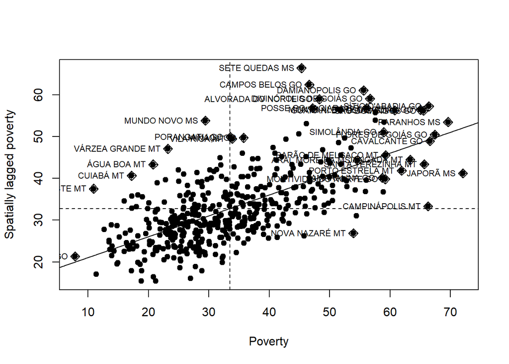

```r
moran.plot(x = shp_co@data$poverty,
           listw = w_list_queen,
           zero.policy = TRUE,
           xlab = "Poverty",
           ylab = "Spatially lagged poverty",
           pch = 19)
```

### Autocorrelação Local de Moran

Criação da Moran Local:

```r
moran_local <- localmoran(x = shp_co@data$poverty,
                          listw = w_list_queen)

moran_local_map <- cbind(shp_co, moran_local)
```

Visualização Espacial:

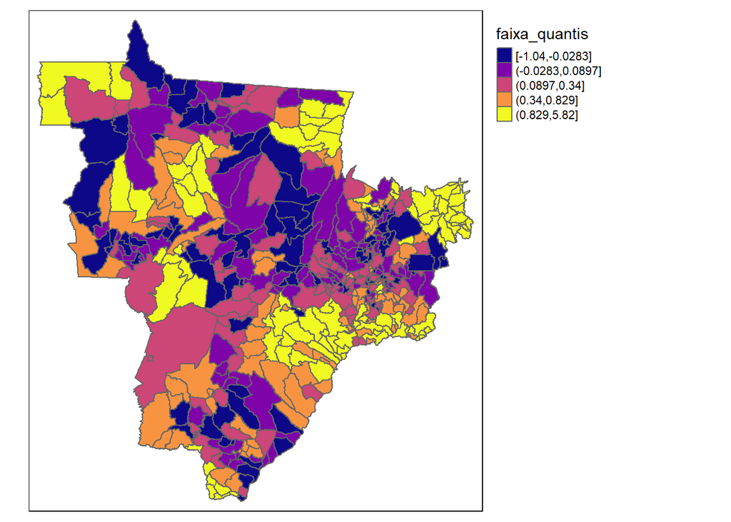

```r
# Ajustes da legenda:
moran_local_map@data <- moran_local_map@data %>%
  mutate(faixa_quantis = factor(quantcut(x = Ii, q = 5)))

# Visualização
moran_local_plot <- tm_shape(shp = moran_local_map) +
  tm_fill(col = "faixa_quantis",
          palette = "plasma") +
  tm_borders() +
  tm_borders() +
  tm_layout(legend.outside = TRUE)

moran_local_plot
```

Plotagem de comparação:

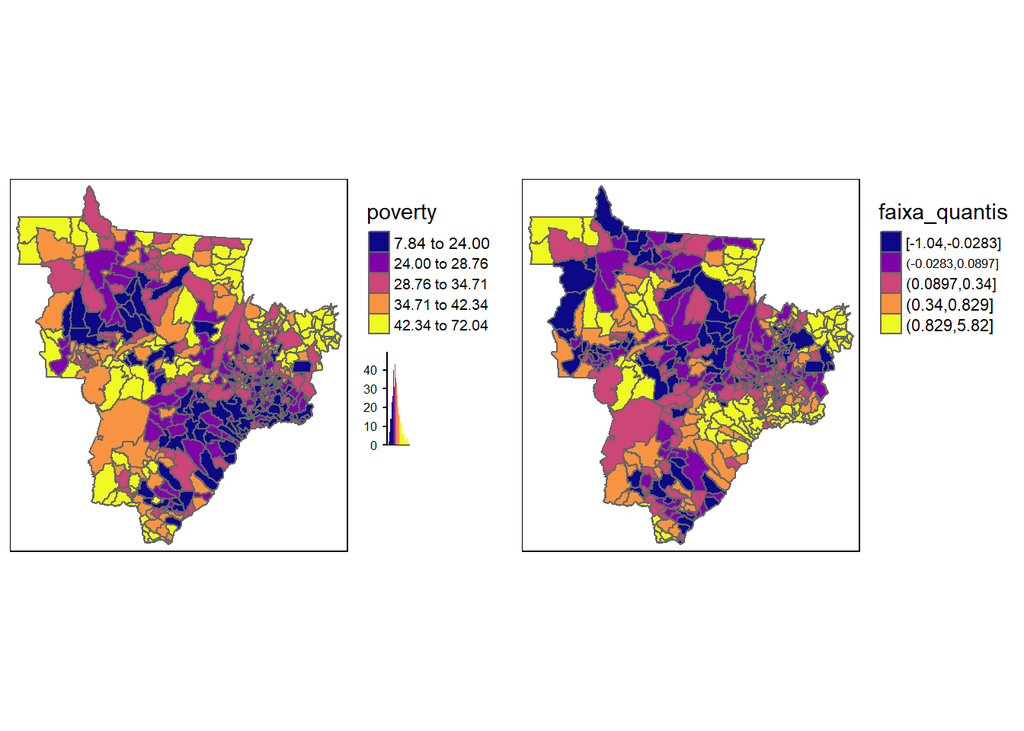

```r
plot.new()
pushViewport(
  viewport(
    layout = grid.layout(1,2)
  )
)
print(pov_plot, vp = viewport(layout.pos.col = 1, height = 5))
print(moran_local_plot, vp = viewport(layout.pos.col = 2, height = 5))
```

Plotagem com rótulos por faixa:

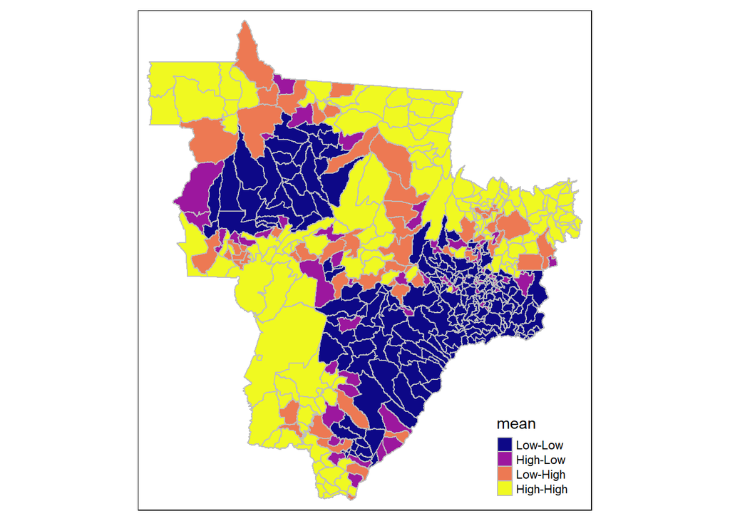

```r
moran_local_map <- cbind(moran_local_map,
                          attr(x = moran_local, which = "quadr")[1])

tm_shape(shp = moran_local_map) +
  tm_fill(col = "mean", palette = "plasma") +
  tm_borders(col = "gray")
```

### Clusterização LISA - Local Indicators of Spatial Association:

```r
quadrantes <- vector(mode = "numeric", length = nrow(moran_local))
```

```r
centro_pov <- shp_co@data$poverty - mean(shp_co@data$poverty)
```

Centro dos valores da Moran Local ao redor da média:

```r
centro_moran_local <- moran_local[,1] - mean(moran_local[,1])
```

Significância a ser adotada:

```r
sig <- 0.05
```

Enquadramento das observações:

```r
quadrantes[centro_pov > 0 & centro_moran_local > 0] <- "HH"
quadrantes[centro_pov > 0 & centro_moran_local < 0] <- "HL"
quadrantes[centro_pov < 0 & centro_moran_local > 0] <- "LH"
quadrantes[centro_pov < 0 & centro_moran_local < 0] <- "LL"
```

Eliminação das observações sem significância estatística:

```r
quadrantes[moran_local[,5] > sig] <- "Estatisticamente_não_significante"
```

União dos objetos:

```r
moran_local_map@data["quadrantes"] <- factor(quadrantes)
```

Visualização gráfica:

```r
tm_shape(shp = moran_local_map) +
  tm_polygons(col = "quadrantes",
              pal = c(HH = "#FDE725FF",
                      HL = "#7AD151FF",
                      LH = "#2A788EFF",
                      LL = "#440154FF",
                      Estatisticamente_não_significante = "white")) +
  tm_borders() +
  tm_layout(legend.outside = TRUE)
```

```
## Some legend labels were too wide. These labels have been resized to 0.63. Increase legend.width (argument of tm_layout) to make the legend wider and therefore the labels larger.
```

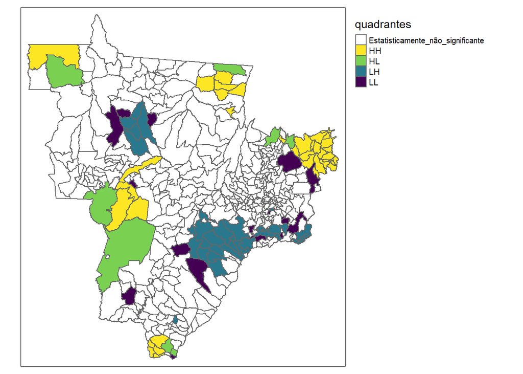

### Autocorrelação Local - Estatística G de Getis e Ord

Estabelecimento do critério de vizinhança (distância geográfica) de 150km:

```r
nb_distan <- dnearneigh(coordinates(shp_co), d1 = 0, d2 = 150, longlat = TRUE)
```

Matriz W:

```r
w_matrix_distan <- nb2mat(neighbours = nb_distan, style = "B")
colnames(w_matrix_distan) <- shp_co@data$MUNICIPIO
rownames(w_matrix_distan) <- shp_co@data$MUNICIPIO
```

Alteração do tipo do objeto (de Matrizw para Listw):

```r
w_list_distan <- mat2listw(x = w_matrix_distan)
```

Estatística G de Getis e Ord:

```r
g_local <- localG(x = shp_co@data$poverty, listw = w_list_distan)
```

União do objeto g_local ao shapefile:

```r
mapa_G <- cbind(shp_co, as.matrix(g_local))

mapa_G@data %>%
  rename(estistica_g = 7) -> mapa_G@data

head(mapa_G@data)
```

```
##    ID CD_GEOCODM     NM_MUNICIP              city state poverty estistica_g
## 1 218    5100102       ACORIZAL       ACORIZAL MT    MT   58.87   1.1798787
## 2 219    5100201       ÁGUA BOA       ÁGUA BOA MT    MT   20.78   1.8912797
## 3 220    5100250  ALTA FLORESTA  ALTA FLORESTA MT    MT   25.20   0.5770763
## 4 221    5100300  ALTO ARAGUAIA  ALTO ARAGUAIA MT    MT   22.84  -2.1531293
## 5 222    5100359 ALTO BOA VISTA ALTO BOA VISTA MT    MT   52.80   2.5741344
## 6 223    5100409    ALTO GARÇAS    ALTO GARÇAS MT    MT   24.34  -0.4287429
```

Visualização gráfica:

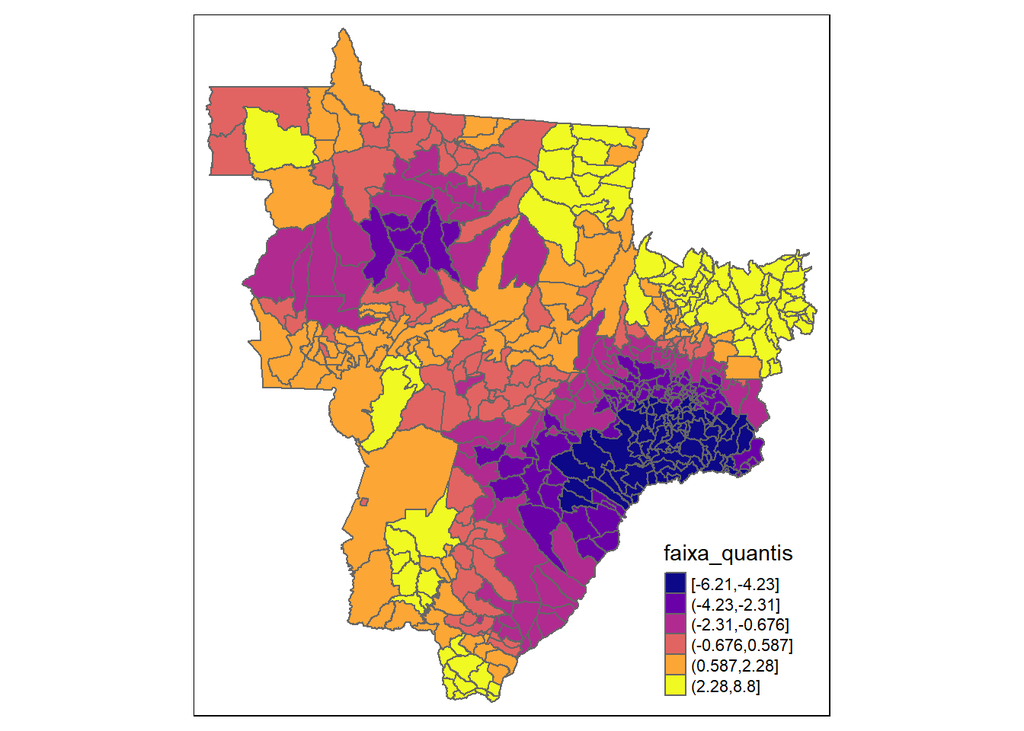

```r
mapa_G@data <- mapa_G@data %>%
  mutate(faixa_quantis = factor(quantcut(x = estistica_g, q = 6)))

tm_shape(mapa_G) +
  tm_fill("faixa_quantis",
          palette = "plasma") +
  tm_borders()
```